# Agrupamiento de Zonas Censales en el Gran Santiago: Análisis Socio-Espacial de Viviendas Precarias e Ingreso Mediante K-Means

Diego Ñanculef

2025-06-29

## 1. Introducción

El siguiente informe tiene como objetivo principal aplicar técnicas de agrupamiento (clustering) para clasificar las zonas censales urbanas del Gran Santiago. Este análisis se fundamenta en la utilización de variables microsimuladas, buscando identificar patrones territoriales latentes que permitan una comprensión más profunda de las dinámicas socio-espaciales de la ciudad.

En el contexto de la desigualdad urbana, la vivienda precaria emerge como una dimensión estructural clave, reflejando no solo condiciones habitacionales deficitarias sino también la convergencia de múltiples determinantes sociales como la seguridad, el acceso a servicios básicos y la conectividad. En el Trabajo 2, se realizó una microsimulación espacial de esta variable, identificando su distribución y concentración en ciertas comunas periféricas del sur y poniente de Santiago, lo cual es coherente con patrones históricos de asentamientos informales y urbanización marginal.

Para enriquecer este análisis y dotar de mayor profundidad a la clasificación territorial, la variable utilizada en el trabajo anterior “V1” (vivienda_precaria) ha sido complementada con la mediana de ingreso per cápita, también obtenida mediante microsimulación y validada en el contexto de este curso. La selección de esta variable de ingreso se justifica plenamente debido a su relevancia intrínseca en el patrón espacial de la precariedad habitacional. Diversas investigaciones y los resultados previos del Trabajo 2 han demostrado una correlación directa entre el tipo de vivienda y el nivel de ingreso: las zonas con mayor proporción de viviendas precarias o informales suelen estar asociadas a ingresos significativamente más bajos, mientras que las viviendas de alta calidad se concentran en sectores de altos ingresos.

La combinación de ambas variables permite ir más allá de la mera descripción de la precariedad para revelar tipologías de zonas que distinguen entre, por ejemplo, áreas de bajo ingreso con presencia de precariedad de vivienda y áreas de bajo ingreso donde esta condición no se observa, proporcionando así una visión más matizada de las realidades urbanas.

Metodológicamente, el trabajo implicará la determinación del número óptimo de grupos mediante el método del codo, la aplicación del algoritmo K-means para la agrupación de las zonas censales y la asignación de etiquetas significativas a cada clúster mediante un análisis estadístico de sus características promedio.

Finalmente, se generarán visualizaciones espaciales a través de mapas temáticos para ilustrar la distribución de estos clusters en el Gran Santiago, así como un mapa adicional que refleje la variabilidad intra-comunal de los clusters utilizando el Índice de Shannon. Se espera que este análisis permita una interpretación territorial profunda de los resultados, reflexionando sobre su coherencia con trabajos anteriores y su utilidad práctica para la planificación urbana y la formulación de políticas públicas.

## 2. Carga de librerías y conexión a Base de Datos

Esta sección establece el entorno computacional necesario para el análisis y prepara el conjunto de datos que será utilizado. Inicialmente, se procede con la carga de las librerías de R pertinentes, incluyendo herramientas para la manipulación y transformación de datos, el manejo de objetos espaciales, la aplicación de algoritmos de clustering, la visualización de datos, y la gestión de bases de datos.

Posteriormente, se establece una conexión directa con la base de datos PostgreSQL, que alberga la información censal y espacial requerida.

```r
# INSTALAR TODAS LAS LIBRERIAS SOLO 1 VEZ
# =============================================================================
# Estos paquetes permiten conexión a BD, manejo de geometrías y visualización
# install.packages(c("DBI", "RPostgres", "sf", "ggplot2", "tidyverse", "cluster", "viridis", "factoextra", "vegan", "entropy", "GGally", "tibble", "tidyr"))

# =============================================================================
# Cargar librerías necesarias
library(tidyverse)
library(sf)
library(cluster)
library(factoextra)
library(ggplot2)
library(viridis)
library(DBI)
library(RPostgres)
library(GGally)   # Para ggpairs
library(entropy)  # Para el índice de Shannon
library(vegan)    # Alternativa para el índice de Shannon (aunque entropy ya sirve)
library(tibble)   # Para crear tibbles, útil para las etiquetas de clusters
library(tidyr)    # Para pivot_wider

# Configurar parámetros de conexión a la base de datos
db_host     = "localhost"
db_port     = 5432
db_name     = "censo_rm_2017"
db_user     = "postgres"
db_password = "postgres"

# Establecer conexión usando RPostgres
con = dbConnect(
  Postgres(),
  dbname    = db_name,
  host      = db_host,
  port      = db_port,
  user      = db_user,
  password = db_password
)
```

## 2.1. Carga y preparación de datos

A través de consultas SQL específicas, se extraen las variables clave para este estudio: el porcentaje de vivienda_precaria (derivado de la microsimulación del Trabajo 2) y la mediana_ingreso per cápita (variable microsimulada en clase). Ambas series de datos, asociadas a sus respectivos geocodigos de zona censal, son subsiguientemente unificadas en un único dataframe. Durante este proceso de preparación, se realiza un filtrado inicial para asegurar la integridad y consistencia del conjunto final, excluyendo aquellas zonas censales que presenten valores nulos (NAs) en estas variables seleccionadas, lo que garantiza la calidad del insumo para las etapas posteriores del análisis de agrupamiento.

# 3. Exploración de Datos

Esta parte es fundamental para comprender las características inherentes de las variables que serán utilizadas en el proceso de agrupamiento. En esta sección, se presenta un análisis descriptivo centrado en la distribución de la variable de % de viviendas precarias y la mediana de ingreso per cápita a través de histogramas. Este examen visual permite identificar patrones clave como la forma de la distribución (normal, sesgada), la presencia de valores atípicos, y la concentración de datos en ciertos rangos, como la notable acumulación de zonas con 0% de viviendas precarias. Los comentarios asociados a cada gráfico detallarán las observaciones más relevantes, como la asimetría de los datos de ingreso o la particular distribución de la precariedad de vivienda, sentando las bases para el preprocesamiento y la aplicación del algoritmo de clustering.

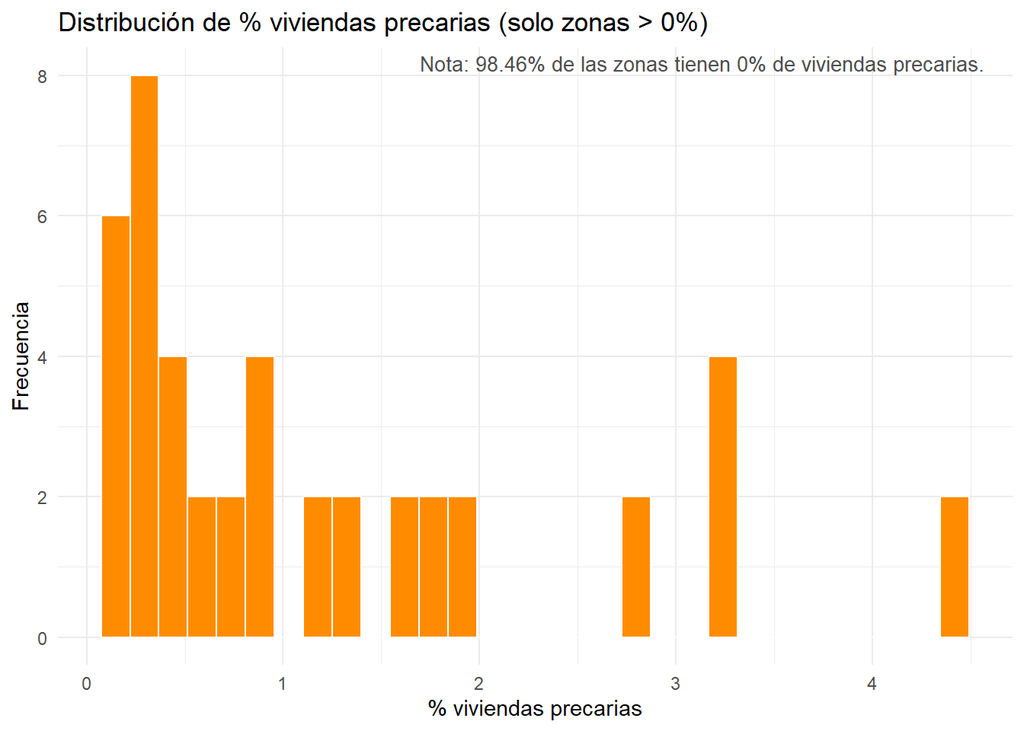

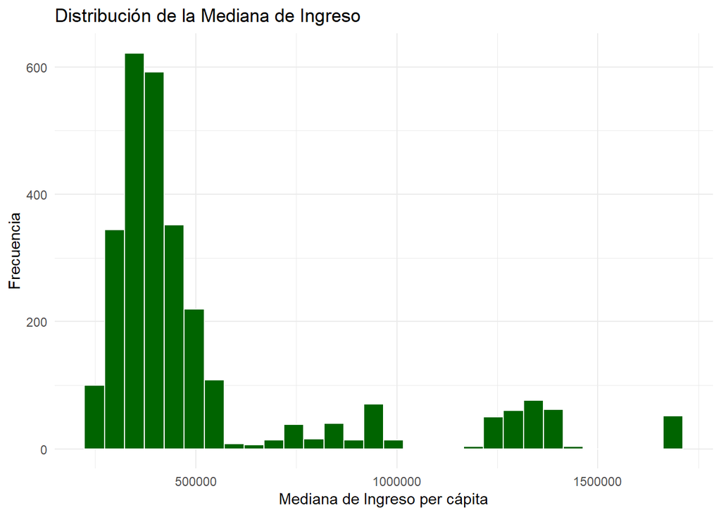

### 3.1. Interpretación del gráfico “Distribución de % viviendas precarias (solo zonas > 0%)”

La primera imagen muestra un histograma de vivienda_precaria excluyendo las zonas que tienen 0% de viviendas precarias y lo que nos indica es lo siguiente:

- Gran Concentración de Ceros: La nota en la esquina superior derecha es fundamental: “Nota: 98.46% de las zonas tienen 0% de viviendas precarias”. Esto significa que la inmensa mayoría de las zonas censales en tu dataset (casi el 98.5%) no registran viviendas precarias según tu definición o la fuente de datos. Esto es un hallazgo muy importante por sí mismo.
- Distribución de la “Minoría Precaria”: Para el 1.54% restante de las zonas (las que sí tienen precariedad), la distribución de vivienda_precaria es la siguiente:
  - Existe una alta concentración de zonas con porcentajes muy bajos de viviendas precarias (entre 0% y aproximadamente 0.5%). De hecho, la barra más alta está muy cerca de 0, lo que sugiere que incluso entre las zonas con precariedad, esta suele ser marginal en términos de porcentaje.
  - A medida que aumenta el porcentaje de viviendas precarias, la frecuencia de zonas disminuye drásticamente.
  - Sin embargo, hay algunas zonas dispersas con porcentajes más altos, incluso llegando a valores por encima del 3%. Estas zonas, aunque pocas, representan casos donde la precariedad de vivienda es más significativa. Esto podría indicar focos específicos de precariedad.
- Discontinuidad / Gaps: Se observan “huecos” en el histograma, donde no hay zonas con ciertos rangos de porcentaje de viviendas precarias. Esto podría deberse a la naturaleza de los datos (tal vez los porcentajes se redondean o se agrupan de alguna manera) o simplemente a que hay muy pocas observaciones en general para esta variable cuando se excluyen los ceros.

En resumen, la precariedad habitacional, según la variable vivienda_precaria, es un fenómeno muy poco extendido en la mayoría de las zonas, pero cuando ocurre, tiende a ser en porcentajes bajos, aunque con casos aislados de mayor intensidad. Esto sugiere que la precariedad es más un problema focalizado que generalizado a nivel de zona censal.

### 3.2. Interpretación del gráfico “Distribución de la Mediana de Ingreso”

En resumen, la mayoría de las zonas censales en el Gran Santiago tienen medianas de ingreso per cápita en el rango medio-bajo, pero existe una minoría de zonas con ingresos significativamente más altos, lo que refleja la desigualdad económica y la concentración de riqueza en ciertos sectores de la ciudad.

# 4. Agrupamiento (Clustering)

En esta sección se implementa el algoritmo de agrupamiento para clasificar las zonas censales urbanas de Santiago en grupos homogéneos, basándose en sus características de vivienda_precaria y mediana_ingreso. El proceso comienza con el escalado de las variables, un paso crítico para asegurar que ninguna de ellas domine el cálculo de distancias debido a diferencias en su escala original. Posteriormente, se procede a determinar el número óptimo de clusters (K), utilizando para ello el método del codo. Finalmente, se aplica el algoritmo K-means con el número de grupos establecido, lo que permitirá segmentar el territorio en distintas tipologías socio-residenciales para un análisis más profundo y la posterior interpretación de los patrones espaciales.

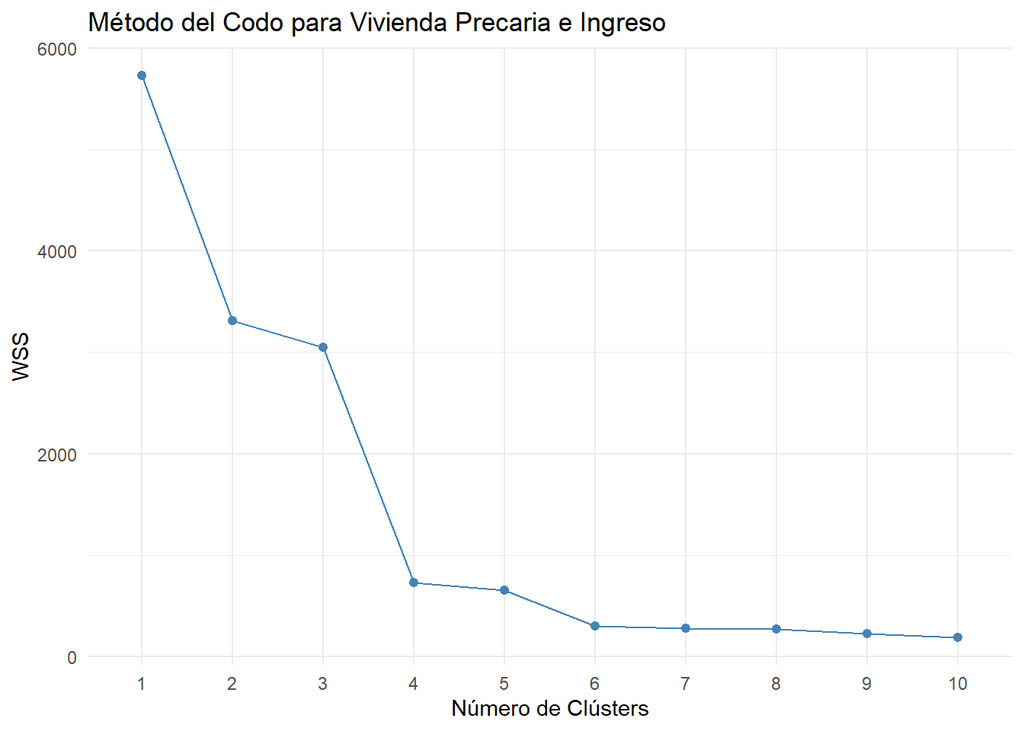

El principio del método del codo es buscar el punto en la curva donde la disminución de WSS (la “inercia” o la varianza dentro de los clusters) comienza a ralentizarse significativamente, formando un “codo” en la gráfica. Después de este punto, añadir más clusters no proporciona una mejora sustancial en la compactibilidad de los clusters.

# 5. Caracterización y Etiquetado de los Grupos

## 5.1. Promedios de los Clusters

Esta subsección presenta el resumen estadístico de las características de cada grupo identificado por el algoritmo K-means.

```r
# Resumen de los clusters para confirmación (Punto 11 en el código original)
cluster_summary <- df_clusters %>%
  group_by(cluster) %>%
  summarise(
    promedio_vivienda_precaria = mean(vivienda_precaria, na.rm = TRUE),
    promedio_ingreso = mean(mediana_ingreso, na.rm = TRUE),
    n_zonas = n()
  ) %>%
  arrange(promedio_vivienda_precaria) # Ordenar para una mejor interpretación
print(cluster_summary) # Para que la tabla se muestre en el output
```

```
## # A tibble: 4 × 4
##   cluster promedio_vivienda_precaria promedio_ingreso n_zonas
##   <fct>                        <dbl>            <dbl>   <int>
## 1 2                          0               1380677.     308
## 2 1                          0.00525          386561.    2330
## 3 4                          0.00632          852172.     212
## 4 3                          2.56             391164.      16
```

La siguiente tabla detalla los valores promedio de % de viviendas precarias y mediana de ingreso per cápita para cada uno de los clusters, así como el número total de zonas censales que pertenecen a cada agrupación. Este análisis descriptivo es fundamental para comprender el perfil distintivo de cada cluster y para fundamentar la asignación de etiquetas significativas que reflejen sus particularidades socio-habitacionales.

## 5.2. Interpretación y Etiquetado Descriptivo

El etiquetado de los grupos (clusters) se realizó basándose en el análisis estadístico de sus características promedio en las variables de vivienda_precaria y mediana_ingreso. El algoritmo K-means agrupa las zonas que son similares entre sí en estas dos dimensiones. Una vez que se obtienen los clusters, se calcula la media de cada variable para cada grupo. Estas medias son las que permiten “entender” qué representa cada clúster y, por lo tanto, asignarle una etiqueta descriptiva.

- Clúster 1 (n=2330 zonas): “Ingreso Medio-Bajo - Sin Precariedad”

Este es el grupo más grande y representa la norma en la provincia de Santiago. Su valor de promedio_vivienda_precaria es prácticamente 0% (0.00525%), indicando la ausencia casi total de precariedad de vivienda. Su promedio_ingreso ($386,561) se sitúa en un rango medio-bajo en comparación con los otros clusters, lo que justifica la parte de “Ingreso Medio-Bajo”.

- Clúster 3 (n=16 zonas): “Alta Precariedad - Ingreso Medio-Bajo”

Este es el clúster más distintivo en términos de vivienda_precaria, con un promedio de 2.56%. A pesar de esta alta precariedad, su promedio_ingreso ($391,164) es muy similar al del Clúster 1 (Ingreso Medio-Bajo). Esto es clave, ya que no son las zonas con los ingresos más bajos per se, sino que presentan un desafío particular de vivienda a pesar de un ingreso no extremo. Su reducido tamaño (16 zonas) indica que estas áreas son focos específicos.

En resumen, las etiquetas se derivan directamente de los patrones promedio que emergen en cada grupo, permitiendo una interpretación clara de las características socioeconómicas y habitacionales que los definen.

# 6. Visualización de Resultados y Análisis Espacial

Esta sección es fundamental para comprender las tipologías de zonas censales identificadas y su distribución geográfica en el Gran Santiago. A través de una serie de visualizaciones, se explorará la relación entre las variables utilizadas para el clustering, se mapearán los grupos resultantes a nivel espacial, y se analizará la variabilidad de estas tipologías dentro de las comunas, ofreciendo una perspectiva integral sobre la estructura socio-espacial de la ciudad.

## 6.1. Carga de Geometrías y Unión de Datos

## 6.2. Gráfico de Dispersión de Clusters

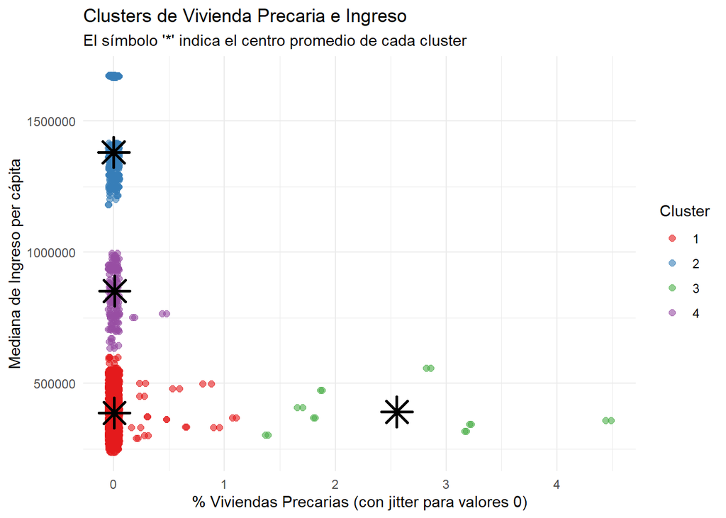

```r
# Calcular estadísticas de los clusters para una mejor comprensión visual de los centros
cluster_summary_plot <- df_clusters %>%
  group_by(cluster) %>%
  summarise(
    avg_vivienda_precaria = mean(vivienda_precaria, na.rm = TRUE),
    avg_mediana_ingreso = mean(mediana_ingreso, na.rm = TRUE),
    etiqueta_descriptiva = first(etiqueta_descriptiva) # Para tener las etiquetas en el summary
  )

# Gráfico mejorado de Vivienda Precaria vs Ingreso (color por cluster)
ggplot(df_clusters, aes(x = vivienda_precaria, y = mediana_ingreso, color = cluster)) +
  geom_point(position = position_jitter(width = 0.05, height = 0), size = 2, alpha = 0.6) +
  # Añadir puntos medios de los clusters para ver el "centro" de cada grupo
  geom_point(data = cluster_summary_plot,
             aes(x = avg_vivienda_precaria, y = avg_mediana_ingreso, color = NULL), # color=NULL para que el asterisco sea negro por defecto
             size = 6, shape = 8, color = "black", stroke = 1.5,
             inherit.aes = FALSE) +
  labs(
    title = "Clusters de Vivienda Precaria e Ingreso",
    subtitle = "El símbolo '*' indica el centro promedio de cada cluster",
    x = "% Viviendas Precarias (con jitter para valores 0)",
    y = "Mediana de Ingreso per cápita"
  ) +
  scale_color_brewer(palette = "Set1", name = "Cluster") + # Aquí sigue mostrando 1,2,3,4 en la leyenda
  theme_minimal()
```

El gráfico muestra los puntos de datos (zonas censales) coloreados según el cluster al que pertenecen, y los asteriscos negros representan el centro promedio (la media) de vivienda_precaria y mediana_ingreso para cada cluster.

Lo que se puede observar nos indica que:

1. La concentración en vivienda_precaria = 0:
   - Como ya había anticipado, la vasta mayoría de los puntos se agrupan en el eje Y, donde el % de viviendas precarias es 0 (o muy cercano a 0, gracias al jitter).
   - Dentro de esta “columna” en x = 0, podemos distinguir claramente la separación de tres clusters principales (1, 2 y 4) basados en su mediana de Ingreso per cápita. Esto es lógico, ya que la precariedad es 0 para ellos, y el algoritmo de K-Means busca la mejor separación posible con las variables que tiene.
2. Los Clusters en vivienda_precaria = 0:
   - Cluster 1 (Rojo): Parece ser el cluster de “Ingreso Bajo” entre las zonas sin precariedad o con muy baja precariedad. Su centro promedio está en la parte inferior de la columna x=0.
   - Cluster 4 (Morado): Representa el cluster de “Ingreso Medio” entre las zonas sin o con muy baja precariedad. Su centro promedio está en el medio de la columna x=0.
   - Cluster 2 (Azul): Corresponde al cluster de “Ingreso Alto” entre las zonas sin o con muy baja precariedad. Su centro promedio se ubica en la parte superior de la columna x=0.
3. El Cluster con vivienda precaria mayor a 0:
   - Cluster 3 (Verde): Este es el cluster más interesante y el que se distribuye a lo largo del eje X, mostrando porcentajes de vivienda_precaria mayores a 0. Su centro promedio también se ubica claramente en un valor de vivienda_precaria significativo (alrededor del 2.5-3%).
   - Se observa que los puntos de este Cluster 3 tienen una mediana_ingreso generalmente más baja que los clusters de “Ingreso Medio” y “Ingreso Alto” (Clusters 4 y 2), y se solapan más con el Cluster 1 (Ingreso Bajo). Esto sugiere una posible relación inversa: a mayor precariedad, menor ingreso.

Basandonos en la visualización, podríamos empezar a etiquetar los clusters de la siguiente manera:

- Cluster 1 (Rojo): Zonas de Bajo Ingreso y Muy Baja/Nula Precariedad de Vivienda.
- Cluster 2 (Azul): Zonas de Alto Ingreso y Muy Baja/Nula Precariedad de Vivienda.
- Cluster 3 (Verde): Zonas con Alguna Precariedad de Vivienda y Mediana de Ingreso Variada (pero generalmente no alta). Podría ser un cluster de “Precariedad moderada a alta”.
- Cluster 4 (Morado): Zonas de Medio Ingreso y Muy Baja/Nula Precariedad de Vivienda.

## 6.3. Matriz de Relación entre Variables por Cluster

Esta subsección presenta una matriz de gráficos de dispersión y densidades bivariadas, construida a partir de las variables vivienda_precaria y mediana_ingreso. La visualización está coloreada según el cluster al que pertenece cada zona censal, permitiendo una exploración detallada de las relaciones entre estas variables dentro de cada grupo. Esto facilitará la observación de cómo se distribuyen y se interrelacionan las características de ingreso y precariedad habitacional en el espacio multidimensional definido por los clusters.

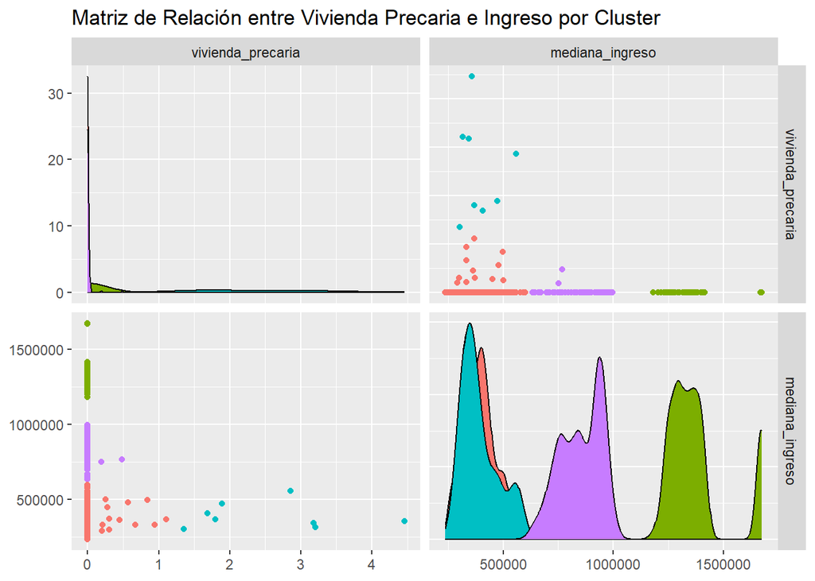

La matriz de relación bivariada, con los puntos coloreados por cluster, ofrece una visión consolidada de la distribución de las zonas censales en función de la vivienda_precaria y la mediana_ingreso, y cómo los clusters se segregan en este espacio.

- Panel de Dispersión (inferior izquierda / superior derecha): Confirma visualmente la separación de los clusters que ya se observó en el gráfico de dispersión anterior. Se puede apreciar claramente cómo los Clusters 1, 2 y 4 se agrupan en el eje de vivienda_precaria cercana a cero, diferenciándose principalmente por su nivel de ingreso. El Clúster 3, por su parte, se distingue por presentar valores más elevados de vivienda_precaria, con un rango de ingresos que se solapa predominantemente con el Clúster 1.
- Paneles de Densidad (diagonal): Las densidades coloreadas por cluster en la diagonal (densityDiag) son particularmente reveladoras. Permiten observar la distribución de cada variable por separado para cada cluster. Por ejemplo, en la densidad de vivienda_precaria, se ve cómo la mayoría de los clusters (1, 2, 4) tienen su densidad concentrada en cero, mientras que el Clúster 3 muestra una densidad desplazada hacia valores positivos. De manera similar, en la densidad de mediana_ingreso, se visualiza claramente cómo cada cluster ocupa un rango específico, validando las etiquetas de ingreso que se asignaron.

En síntesis, esta matriz refuerza la comprensión de las tipologías de clusters, mostrando de forma compacta las relaciones internas y las diferencias entre grupos en las dos dimensiones clave del análisis.

## 6.4. Mapa de Clusters por Zona Censal

[figure not shown]

```r
ggplot() +
  geom_sf(data = sf_mapa, aes(fill = etiqueta_descriptiva), color = NA) +
  geom_sf(data = sf_comunas, fill = NA, color = "black", size = 0.4) +
  geom_sf_text(data = st_centroid(sf_comunas), aes(label = nom_comuna), size = 2) +
  scale_fill_brewer(palette = "Set2", name = "Tipo de Zona Censal") +
  labs(title = "Distribución Espacial de Tipologías de Zonas Censales Urbanas en el Gran Santiago",
       subtitle = "Clusters basados en Vivienda Precaria e Ingreso") +
  coord_sf(xlim = c(bbox["xmin"], bbox["xmax"]), ylim = c(bbox["ymin"], bbox["ymax"]), expand = FALSE) +
  theme_void()
```

El clustering ha logrado identificar diferentes tipos de zonas censales basadas en vivienda_precaria e ingreso:

1. La mayoría zonas con ingresos medios-bajos y prácticamente sin precariedad habitacional.
2. Zonas Acomodadas: Zonas con ingresos altos y muy altos, y sin precariedad.
3. Zonas de Preocupación: Un pequeño grupo de zonas con alta precariedad habitacional y niveles de ingreso que son similares a las zonas más grandes y de menores ingresos (Cluster 1). Esto resalta un problema focalizado de precariedad que no está necesariamente ligado a los ingresos más bajos de la ciudad, sino a un nivel de ingreso medio-bajo donde, sin embargo, la precariedad de la vivienda es una realidad.

## 6.5. Análisis de la Distribución Espacial

# 7. Variabilidad Intra-Comunal (Índice de Shannon)

Esta sección profundiza en el análisis espacial, yendo más allá de la distribución de los clusters para examinar la diversidad interna de las comunas del Gran Santiago. Para ello, se utiliza el Índice de Shannon, una métrica que permite cuantificar la heterogeneidad de los clusters dentro de cada unidad administrativa. Los resultados de este análisis, presentados a través de un mapa temático, serán cruciales para entender qué comunas son más homogéneas en términos de sus tipologías socio-residenciales y cuáles exhiben una mayor mezcla de grupos, lo que tiene implicaciones directas para la planificación y la formulación de políticas públicas a escala local.

## 7.1. Cálculo y Mapa del Índice de Shannon

Se detalla la metodología de cálculo del Índice de Shannon aplicado a los clusters previamente definidos. El índice se computa para cada comuna del Gran Santiago, reflejando la distribución proporcional de los diferentes tipos de clusters dentro de sus límites geográficos. Posteriormente, se visualizan estos resultados mediante un mapa comunal, donde la escala de color indicará el nivel de diversidad de clusters, permitiendo identificar rápidamente las áreas con mayor o menor heterogeneidad en sus patrones socio-residenciales.

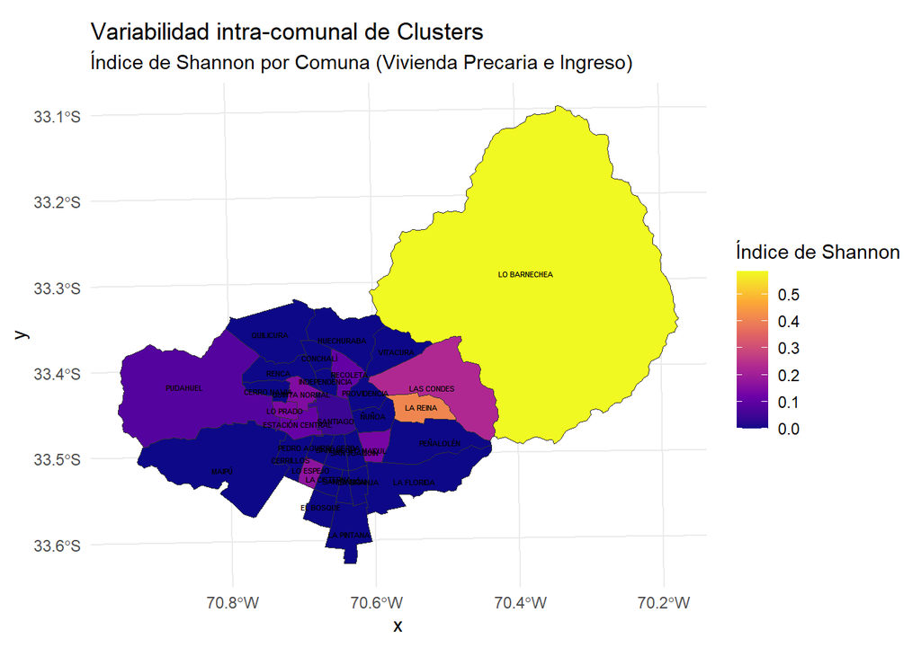

```r
# Crear tabla de frecuencia de clusters por comuna
tabla_shannon <- sf_mapa %>%
  st_drop_geometry() %>%
  group_by(nom_comuna, cluster) %>% # Usamos el ID numérico del cluster aquí
  summarise(n = n(), .groups = "drop") %>%
  pivot_wider(
    names_from = cluster, # Pivotar por el ID numérico del cluster
    values_from = n,
    values_fill = 0
  )

# Calcular índice de Shannon
cluster_columns_for_shannon <- colnames(tabla_shannon)[!colnames(tabla_shannon) %in% c("nom_comuna")]
tabla_shannon$shannon <- diversity(tabla_shannon[, cluster_columns_for_shannon], index = "shannon")

# Unión con geometría comunal
sf_shannon <- sf_comunas %>%
  left_join(tabla_shannon, by = "nom_comuna")

# Mapa de variabilidad intra-comunal
ggplot(sf_shannon) +
  geom_sf(aes(fill = shannon), color = "grey20", size = 0.3) +
  geom_sf_text(aes(label = nom_comuna), size = 1.5, color = "black") +
  scale_fill_viridis_c(option = "plasma", name = "Índice de Shannon") +
  labs(
    title = "Variabilidad intra-comunal de Clusters",
    subtitle = "Índice de Shannon por Comuna (Vivienda Precaria e Ingreso)"
  ) +
  theme_minimal()
```

## 7.2. Interpretación de los resultados y Utilidad territorial

Por otro lado, el significado de los valores Bajos del Índice de Shannon (Colores Morados/Azules Oscuros) nos indican una menor diversidad de clusters dentro de esa comuna. Estas comunas son más homogéneas en su composición de zonas censales. Las comunas del poniente y sur de Santiago (ej. Pudahuel, Maipú, San Bernardo, Lo Espejo) presentan índices bajos. Esto sugiere que están predominantemente compuestas por uno o dos tipos de clusters, siendo el Clúster 1 (‘Ingreso Medio-Bajo - Sin Precariedad’) el más probable dominante, lo que resalta una uniformidad socioeconómica a gran escala en estas áreas.

## 7.3. Conclusiones del mapa

Este mapa es una poderosa herramienta para identificar dónde se concentran las diferentes realidades socioeconómicas y dónde hay mayor variabilidad dentro de las unidades administrativas de la ciudad.

# 8. Reflexión final y valor agregado

El análisis de clusters realizado en este trabajo, junto con la combinación de la variable de vivienda_precaria (microsimulada en el Trabajo 2) y la mediana_ingreso per cápita, representa un avance sustancial en la comprensión de la desigualdad socio-espacial en el Gran Santiago.

Mientras que el Trabajo 2, con la microsimulación de la variable de vivienda, ya mostraba una importante heterogeneidad espacial y una clara concentración de viviendas precarias o informales en comunas del sur y poniente (como Lo Espejo, Pedro Aguirre Cerda y La Pintana) y sectores de Cerro Navia, los resultados de este nuevo trabajo son altamente coherentes con esas observaciones, confirmando la existencia de focos de precariedad y zonas de alto ingreso sin precariedad habitacional en los sectores orientales.

Sin embargo, la principal fortaleza y el valor agregado crucial de este Trabajo 3 reside en su capacidad para trascender la descripción univariable y generar tipologías territoriales complejas. Si bien el Trabajo 2 permitió identificar dónde se localizaba la precariedad de vivienda y dónde se concentraban los altos ingresos, el análisis de clusters va más allá al identificar perfiles de zonas censales que combinan ambas dimensiones de manera simultánea. Un avance clave, por ejemplo, es la distinción entre el Clúster 1 (‘Ingreso Medio-Bajo - Sin Precariedad’) y el Clúster 3 (‘Alta Precariedad - Ingreso Medio-Bajo’). Ambos comparten niveles de ingreso similares, pero el Clúster 3 se diferencia crucialmente por la presencia de precariedad. Esto revela que la problemática de la vivienda precaria no es un fenómeno exclusivo de las zonas de más bajos ingresos absolutos, sino que puede presentarse en contextos de ingresos medios-bajos donde la calidad de la vivienda es el factor determinante de vulnerabilidad.

Asimismo, la identificación de múltiples clusters de “no precariedad” pero con distintos niveles de ingreso (Clusters 1, 2 y 4) permite una visión más matizada de las zonas urbanas, distinguiendo entre áreas de diferentes estratos socioeconómicos que, sin embargo, comparten la característica de no presentar precariedad habitacional significativa. Este análisis de clustering ofrece, por lo tanto, una visión más integral y multidimensional de la desigualdad, superando una simple correlación lineal entre ingreso y vivienda al identificar grupos de zonas con perfiles combinados y complejos.

El conocimiento de la distribución de estos grupos es de inmensa utilidad para la formulación de políticas públicas y la planificación territorial:

- Focalización de Políticas Públicas: Permite una focalización mucho más precisa. Por ejemplo, el Clúster 3 (Alta Precariedad - Ingreso Medio-Bajo) se convierte en un objetivo claro para programas de mejoramiento de vivienda, subsidios o intervenciones barriales, ya que son zonas con una necesidad crítica de vivienda que quizás no serían identificadas si solo se usara un umbral de ingreso bajo.
- Asignación de Recursos: Facilita una asignación más eficiente y equitativa de recursos, dirigiendo las inversiones directamente donde la combinación de precariedad y nivel de ingreso demanda una intervención específica.
- Comprensión de la Estructura Urbana: Proporciona a los planificadores urbanos una herramienta para entender la heterogeneidad y homogeneidad interna de las comunas. Las comunas con alta variabilidad de clusters (reflejada en el Índice de Shannon) requerirán un enfoque de planificación y gestión más diversificado y contextualizado.
- Monitoreo y Evaluación: Establece una línea base para monitorear los efectos de las intervenciones a lo largo del tiempo y evaluar su impacto en la reducción de la precariedad y la mejora de la calidad de vida en los grupos más vulnerables.

En síntesis, si bien el Trabajo 2 brindó la base de datos de viviendas precarias a nivel desagregado, este nuevo trabajo, mediante el uso de clustering, ha transformado esa información en un marco analítico de tipologías territoriales. Esto permite una comprensión más profunda de las interacciones entre ingreso y calidad de vivienda, lo cual es fundamental para tomar decisiones de política pública más informadas y efectivas.

# 9. Conclusión

El presente estudio ha logrado clasificar las zonas censales urbanas del Gran Santiago en cuatro tipologías distintivas, basadas en la combinación de sus niveles de vivienda precaria y mediana de ingreso per cápita. Esta aproximación ha permitido trascender la descripción univariable para ofrecer una comprensión más granular y multidimensional de la estructura socio-espacial del área metropolitana.

La visualización espacial de estos clusters a nivel de zona censal ha corroborado la persistencia de patrones de segregación socio-espacial en el Gran Santiago. Los clusters de alto ingreso se concentran visiblemente en el sector oriente, mientras que el Clúster 1 de ingreso medio-bajo sin precariedad domina las comunas del centro, sur y poniente. Más allá de la segregación general, este análisis ha permitido identificar con precisión aquellos focos de precariedad (Clúster 3) que, si bien son pocos, representan desafíos específicos para la política habitacional.

En retrospectiva, este Trabajo 3 ha enriquecido sustancialmente los hallazgos del Trabajo 2. Mientras que la microsimulación inicial permitió mapear la distribución de la vivienda precaria, el análisis de clustering ha transformado esta información en conocimiento accionable al definir tipologías de zonas. Este enfoque multidimensional no solo confirma la concentración de precariedad en sectores previamente identificados, sino que también distingue entre zonas con ingresos similares, pero con calidades de vivienda radicalmente distintas. Este valor agregado es vital para la focalización de políticas públicas, permitiendo una asignación más eficiente y equitativa de recursos para el mejoramiento habitacional y la reducción de la desigualdad urbana, al identificar con mayor precisión los grupos de población y los territorios que requieren intervenciones específicas. La capacidad de identificar estos patrones espaciales y la variabilidad interna de las comunas posiciona este análisis como una herramienta robusta para la toma de decisiones en planificación territorial y políticas sociales.

# 10. Desconexión a la base de datos